# p8105_hw5_fwt2107

Felix Tran

November 3, 2018

# Problem 1

1. Create function **tidy_subject_data()** which will be used later to tidy the subject data.
2. Read in all file names
3. Read in the data contained in those files to form a new variable of lists in the tibble (each file’s data is an individual dataset)
4. Remove the ‘.csv’ from the file names to leave the subject number and treatment arm
5. Plot spaghetti plot of subject scores over time by treatment group

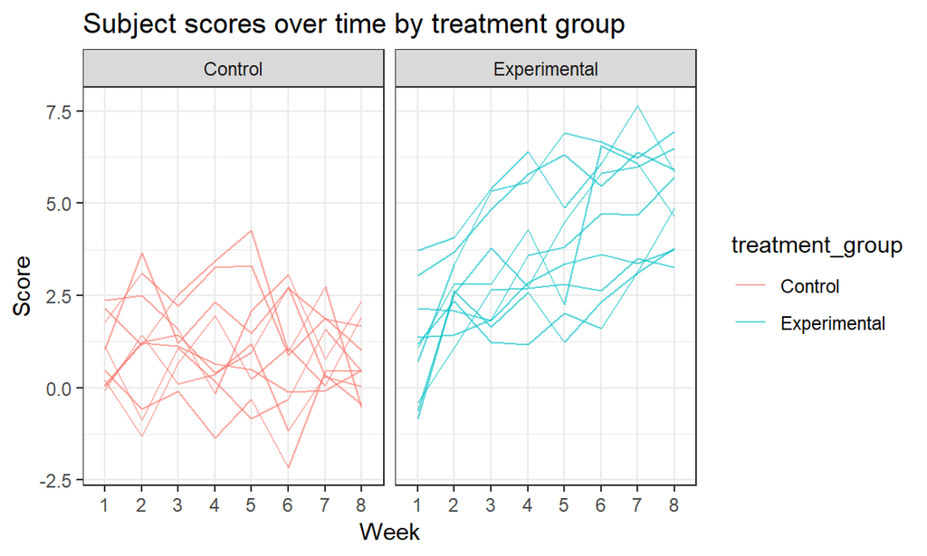

```r
tidy_subject_data <- function(df) {
    gather(data = df, key = 'week', value = 'score', week_1:week_8) %>%
    separate(col = week, into = c('deleteable', 'week'), sep = '_') %>%
    select(-deleteable)
}

study_df <- tibble(
  file_name = list.files('./hw5_data/data'),
  subject_data = purrr::map(str_c('./hw5_data/data/', file_name),
                            readr::read_csv)
) %>%
  separate(col = file_name, into = c('file_name', 'deletable'), sep = '\\.') %>%
  select(-deletable) %>%
  mutate(subject_data = purrr::map(subject_data, tidy_subject_data),
         treatment_group =
           if_else(str_detect(file_name, 'con'), 'Control', 'Experimental'))
study_df %>%
  unnest %>%
  ggplot(aes(x = week, y = score, color = treatment_group, group = file_name)) +
  geom_line(alpha = 0.6) +
  facet_grid(. ~ treatment_group) +
  labs(title = 'Subject scores over time by treatment group',
       x = 'Week',
       y = 'Score')
```

At the start of the study, the experimental group scores ranged between -1 to 4, while the control group ranged between 0 to 2.5. The scores in the control group as a whole remained unchanged by the end of the study. However, the scores in the experimental group as a whole increased, placing the experimental group between 2.5 to 7.5 points.

# Problem 2

### Describing the raw data

The raw data contains 12 variables:

1. uid - A unique ID for each homicide including the city
2. reported_date - The date when the homicide was reported (YYMMDD)
3. victim_last - Victim’s last name
4. victim_first - Victim’s first name
5. victim_race - Victim’s race
6. victim_age - Victim’s age in years
7. victim_sex - Victim’s sex
8. City - City in which the homicide occurred
9. State - State in which the homicide occurred
10. lat - Latitude where the homicide occurred
11. long - Longitude where the homicide occurred
12. disposition - Describes if the homicide investigation resulted in an arrest, no arrest, or if the case was closed without an arrest being made

```r
data_url <- RCurl::getURL('https://raw.githubusercontent.com/washingtonpost/data-homicides/master/homicide-data.csv')

homicide_df <- readr::read_csv(data_url) %>%
  mutate(victim_age = as.integer(victim_age),
         reported_date = lubridate::ymd(reported_date))
head(homicide_df)
```

```
## # A tibble: 6 x 12
##   uid   reported_date victim_last victim_first victim_race victim_age
##   <chr> <date>        <chr>       <chr>        <chr>            <int>
## 1 Alb-~ 2010-05-04    GARCIA      JUAN         Hispanic            78
## 2 Alb-~ 2010-02-16    MONTOYA     CAMERON      Hispanic            17
## 3 Alb-~ 2010-06-01    SATTERFIELD VIVIANA      White               15
## 4 Alb-~ 2010-01-01    MENDIOLA    CARLOS       Hispanic            32
## 5 Alb-~ 2010-01-02    MULA        VIVIAN       White               72
## 6 Alb-~ 2010-01-26    BOOK        GERALDINE    White               91
## # ... with 6 more variables: victim_sex <chr>, city <chr>, state <chr>,
## #   lat <dbl>, lon <dbl>, disposition <chr>
```

```r
unique(homicide_df$disposition)
```

```
## [1] "Closed without arrest" "Closed by arrest"      "Open/No arrest"
```

```r
prop_male <- round((length(which(homicide_df$victim_sex == 'Male')) /
                nrow(homicide_df)) * 100, digits = 0)

prop_unsolved <- round((length(which(
  homicide_df$disposition != 'Closed by arrest')) / nrow(homicide_df)) * 100,
  digits = 0)
```

The dataset contains information about 52179 homicides which occurred in 50 cities across 28 states between 2007 - 2017. 78% of the victims were male, and the average victim age was 32 years old. 51% of all homicides are unsolved (closed without arrest or open/no arrest).

### Homicides by city

1. Upon inspection of the data, one homicide listed Tulsa as the city but AL as the state. This mistake was corrected by changing the reported state to OK.
2. Create variable **city_state** to concatenate city and state information
3. Count the total number of homicides and the number of unsolved homicides by location

```r
homicide_df <- homicide_df %>%
  mutate(state = if_else(state == 'AL' & city == 'Tulsa', 'OK', state)) %>%
  mutate(city_state = str_c(city, ', ', state))

options(tibble.print_max = Inf)
homicide_df %>%
  group_by(city_state) %>%
  summarize(total_homicides = n(),
            unsolved_homicides =
              length(which(disposition != 'Closed by arrest')))
```

```
## # A tibble: 50 x 3
##    city_state         total_homicides unsolved_homicides
##    <chr>                        <int>              <int>
##  1 Albuquerque, NM                378                146
##  2 Atlanta, GA                    973                373
##  3 Baltimore, MD                 2827               1825
##  4 Baton Rouge, LA                424                196
##  5 Birmingham, AL                 800                347
##  6 Boston, MA                     614                310
##  7 Buffalo, NY                    521                319
##  8 Charlotte, NC                  687                206
##  9 Chicago, IL                   5535               4073
## 10 Cincinnati, OH                 694                309
## 11 Columbus, OH                  1084                575
## 12 Dallas, TX                    1567                754
```

[output cut: 38 more lines]

### Baltimore, MD

1. Repeat the same process as the previous example, but focusing only on Baltimore
2. Use the **prop.test** function to estimate the proportion of homicides that are unsolved in Baltimore with 95% CI.

```r
baltimore_results_df <- homicide_df %>%
  group_by(city_state) %>%
  filter(city_state == 'Baltimore, MD') %>%
  summarize(unsolved_homicides =
              length(which(disposition != 'Closed by arrest')),
            total_homicides = n(),
            prop_results = purrr::map2(unsolved_homicides, total_homicides,
                                       prop.test)) %>%
  select(prop_results) %>%
  broom::tidy(prop_results) %>%
  janitor::clean_names()

balt_unsolved_est <- round(baltimore_results_df$estimate * 100, digits = 0)
balt_unsolved_conf_low <- round((baltimore_results_df$conf_low * 100),
                               digits = 0)
balt_unsolved_conf_high <- round((baltimore_results_df$conf_high * 100),
                                digits = 0)
```

An estimated 65% (95% CI: 63%, 66%) of homicides in Baltimore are unsolved.

### Creating a dataset with the estimate and 95% CI of unsolved homicides in

### all 50 cities

1. Repeat the same process as the previous Baltimore example, but with all 50 cities
2. Use the **prop.test** function to estimate the proportion of homicides that are unsolved in each city with 95% CI.

```r
unsolved_df <- homicide_df %>%
  group_by(city_state) %>%
  summarize(unsolved_homicides =
              length(which(disposition != 'Closed by arrest')),
            total_homicides = n(),
            prop_results = purrr::map2(unsolved_homicides, total_homicides,
                                       prop.test)) %>%
  select(city_state, prop_results) %>%
  mutate(prop_results = purrr::map(prop_results, broom::tidy)) %>%
  unnest %>%
  janitor::clean_names() %>%
  select(city_state, estimate, conf_low, conf_high)
```

### Plotting the newly created dataset

1. Created a function **prop_transform** to transform the values of the estimated proportion and confidence limits for unsolved homicides into percentages
2. Saved the order of the 50 cities according to proportion of unsolved homicides in variable **city_factor_order**
3. Transformed dataset by applying **prop_transform** to the estimated proportion and confidence limits, as well as transforming variable **city_state** into a factor with the values ordered according to **city_factor_order**
4. Plot the estimated proportion of unsolved homicides with 95% CI in the cities

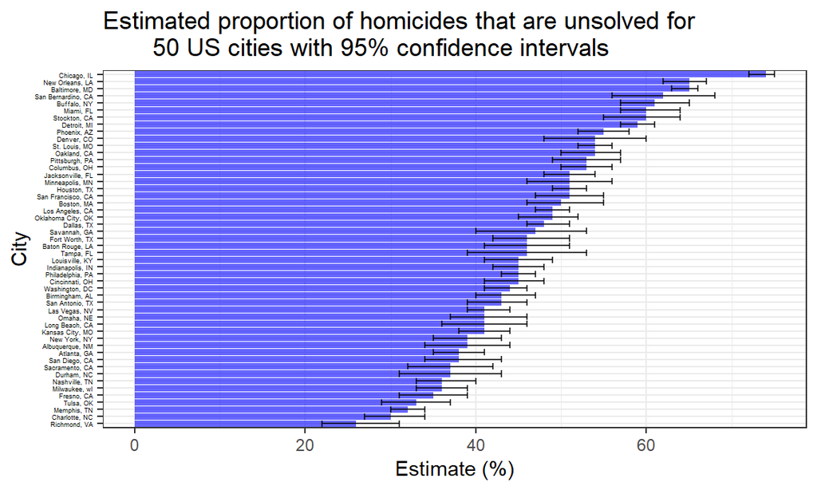

```r
prop_transform <- function(x) {
  round((x * 100), digits = 0)
}

city_factor_order <- unsolved_df$city_state[order(unsolved_df$estimate)]

unsolved_df %>%
  mutate(estimate = prop_transform(estimate),
         conf_low = prop_transform(conf_low),
         conf_high = prop_transform(conf_high),
         city_state = readr::parse_factor(city_state, city_factor_order)) %>%
  ggplot(aes(x = city_state, y = estimate)) +
  geom_bar(stat = "identity", position = position_dodge(width = 0.9),
           fill = 'blue', alpha = 0.6) +
  geom_errorbar(aes(ymin = conf_low, ymax = conf_high), alpha = 0.75) +
  labs(title = 'Estimated proportion of homicides that are unsolved for
       50 US cities with 95% confidence intervals',
       y = 'Estimate (%)',
       x = 'City') +
  coord_flip() +
  theme(axis.text.y = element_text(size = 3.5, color = 'black'))
```